# assignment

2023-03-31

```r
suppressPackageStartupMessages({
  library(AnnotationHub)
  library(GenomicRanges)
  library(ggplot2)
  library(memes) # for the meme-based methods -- COMMENT OUT when using alternatives
  library(motifmatchr)
  library(Biostrings) # for handling sequences
  library(MotifDb) # database of motifs
  library(TFBSTools) # for handling some motif formats
  library(universalmotif) # for converting motifs to various formats
  library(PWMEnrich) # for R-based motif enrichment analysis
})
```

```
## See system.file("LICENSE", package="MotifDb") for use restrictions.
```

# Choose a transcription factor, e.g. CREB1, REST, GATA5, EGR1, GCR (or any of your choice that has a motif and available ChIPseq data)

## Download the (e.g. Mouse) peaks for that factor (in whatever cell type)

## Identify the instances of the factor’s motif

## Answer the following questions:

### Of all the peaks, what proportion contains a motif for the factor?

#### Expected form of an answer: of the XX peaks, XX (XX%) contain a motif

### Of all instances of that motif in the genome (or in one chromosome), what proportion is bound by the factor (i.e. has a peak)?

#### Expected form of an answer: of the XX motif instances, XX (XX%) overlap a peak

#### Don’t forget to render your markdown and push it as assignment.html !

```r
getwd()
```

```
## [1] "/Users/julianortner/Desktop/Master MHS/8. Semester (Master MHS)/Bioinformatic Approaches to Regulatory Genomics and Epigenomics/HW_06/assignment_06"
```

Filtering files: https://www.encodeproject.org/search/?replicates.library.biosample.donor.organism.scientific_name=Mus+musculus&assay_title=TF+ChIP-seq&type=Experiment&target.label=REST

TF ChIP-seq in myocyte Mus musculus myocyte originated from C2C12 Target: REST (Factorbook) Lab: Barbara Wold, Caltech Project: ENCODE https://www.encodeproject.org/files/ENCFF368VWJ/

```r
download.file("https://www.encodeproject.org/files/ENCFF368VWJ/@@download/ENCFF368VWJ.bed.gz", dest="REST_TF_ChIPseq.bed.gz")
peaks <- rtracklayer::import("REST_TF_ChIPseq.bed.gz", format="narrowPeak")
seqlevelsStyle(peaks) <- "Ensembl"  # to change the convention of the chromosome names to ensembl (i.e. without 'chr')
peaks_REST_chr1 <- peaks[seqnames(peaks)=="1"] # peaks found on chromsome 1
```

```r
ah <- AnnotationHub()
```

```
## snapshotDate(): 2022-10-31
```

```r
# display(ah)
```

```r
peak_centers <- resize(peaks_REST_chr1, fix="center", width=100)
peak_centers
```

```
## GRanges object with 214 ranges and 6 metadata columns:
##         seqnames              ranges strand |        name     score signalValue
##            <Rle>           <IRanges>  <Rle> | <character> <numeric>   <numeric>
##     [1]        1   70725718-70725817      * |        <NA>      1000     143.938
##     [2]        1   75263127-75263226      * |        <NA>      1000     140.560
##     [3]        1   75277345-75277444      * |        <NA>      1000     134.697
##     [4]        1 152956367-152956466      * |        <NA>      1000     132.948
##     [5]        1   75479514-75479613      * |        <NA>      1000     123.344
##     ...      ...                 ...    ... .         ...       ...         ...
##   [210]        1   21598285-21598384      * |        <NA>       605    11.60410
##   [211]        1 186117211-186117310      * |        <NA>       580    11.22647
##   [212]        1 159621488-159621587      * |        <NA>       559    10.76565
##   [213]        1 160704004-160704103      * |        <NA>       795    10.60108
##   [214]        1 177555790-177555889      * |        <NA>       605     9.78183
##            pValue    qValue      peak
##         <numeric> <numeric> <integer>
##     [1]        -1   3.97603       110
##     [2]        -1   3.97603       123
##     [3]        -1   3.97603       111
##     [4]        -1   3.97603       111
##     [5]        -1   3.97603       104
##     ...       ...       ...       ...
##   [210]        -1   3.97603        68
##   [211]        -1   3.50211        68
##   [212]        -1   3.52759        68
##   [213]        -1   3.53870        68
##   [214]        -1   3.58984        68
##   -------
##   seqinfo: 20 sequences from an unspecified genome; no seqlengths
```

```r
# resize the peaks to a fixed width of 100 bp centered on the peak summit
# the resulting 'peak_centers' object contains the centers of the peaks

ah <- AnnotationHub(localHub=FALSE)
```

```
## snapshotDate(): 2022-10-31
```

```r
genome <- ah[["AH68356"]]
```

```
## loading from cache
```

```
## require("rtracklayer")
```

```r
# create an AnnotationHub object and get the genome annotation for the organism of interest
# 'AH68356' is the identifier for the genome annotation used in this analysis

peak_seqs <- Biostrings::getSeq(genome, peak_centers)
names(peak_seqs) <- as.character(granges(peak_centers))
# use the 'memes' package to get the DNA sequences corresponding to the peak centers
# the resulting 'peak_seqs' object contains the DNA sequences

peak_seqs
```

```
## DNAStringSet object of length 214:
##       width seq                                             names
##   [1]   100 GGAAGCAGCTGGGGGTTTCGAC...GCTGCCGGCAGGATGAGCTCCG 1:70725718-70725817
##   [2]   100 GGGGCAGCCTGTCCCAGGCAGA...AGACGTTTACCAAGGGAAGGGT 1:75263127-75263226
##   [3]   100 CATGGGGAAACCAGGATCCACA...GGTAATGACAACGCCTTGGCAC 1:75277345-75277444
##   [4]   100 AGGGTGAGAGTCCCTGACCCGG...TGGCTGCGGGCACACGTGTTTG 1:152956367-15295...
##   [5]   100 AAGCAGCCCGCCCCTGCCAGGA...GGCCGCCAGCGGGCTCAGGGCA 1:75479514-75479613
##   ...   ... ...
## [210]   100 CATGCATGCACAGGCATGCACA...CACAAACAGGCACACATGCACA 1:21598285-21598384
## [211]   100 CACAACGCGGCAGGTGAACAGC...AGCGTCACGGGGCCGCGCGCGC 1:186117211-18611...
## [212]   100 TCTGGTGTGATGGACTTCAGCA...ACTCACACATCTCCCCTCTGGG 1:159621488-15962...
## [213]   100 ACTCATGCACACACACATATGC...GCACACACTTGAACCCACTCAT 1:160704004-16070...
## [214]   100 CCCAACTTCAAACATGCAGTCT...CCCCCAGTCCCCTGGCAGGGAG 1:177555790-17755...
```

```r
# display the sequences in the 'peak_seqs' object and display the first sequence as a character string
```

```r
# we search for "REST" in the motif database
# this line searches for motifs related to the transcription factor of interest in a motif database
# the second argument to the 'query' function is the name of the transcription factor
# in this case, the transcription factor is 'REST'

motifs <- query(MotifDb, "REST")
# assign the results of the motif search to the variable 'motifs'

motifs
```

```
## MotifDb object of length 15
## | Created from downloaded public sources, last update: 2022-Mar-04
## | 15 position frequency matrices from 10 sources:
## |        HOCOMOCOv10:    2
## | HOCOMOCOv11-core-A:    1
## |              HOMER:    1
## |        JASPAR_2014:    1
## |        JASPAR_CORE:    1
## |         jaspar2016:    2
## |         jaspar2018:    2
## |         jaspar2022:    1
## |       SwissRegulon:    1
## |           UniPROBE:    3
## | 3 organism/s
## |           Hsapiens:   10
## |          Mmusculus:    4
## |              other:    1
## Hsapiens-HOCOMOCOv10-REST_HUMAN.H10MO.A
## Mmusculus-HOCOMOCOv10-REST_MOUSE.H10MO.A
## Hsapiens-HOCOMOCOv11-core-A-REST_HUMAN.H11MO.0.A
## NA-HOMER-REST-NRSF(Zf)/Jurkat-NRSF-ChIP-Seq/Homer
## Hsapiens-JASPAR_CORE-REST-MA0138.2
## ...
## Hsapiens-jaspar2022-REST-MA0138.2
## Hsapiens-SwissRegulon-REST.SwissRegulon
## Mmusculus-UniPROBE-Irx3.UP00223
## Mmusculus-UniPROBE-Irx3.UP00223.a272
## Mmusculus-UniPROBE-Irx6.UP00150
```

```r
# display the 'motifs' variable to see the motifs that were found
```

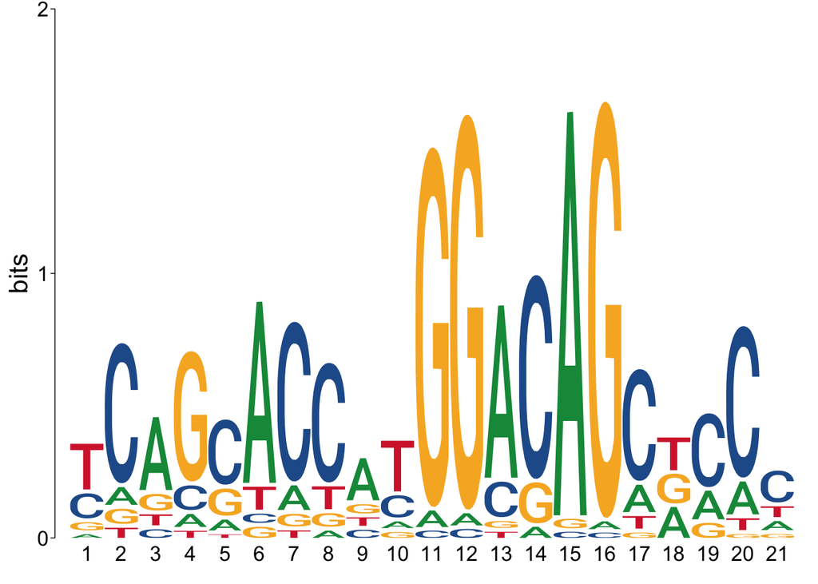

```r
motif <- motifs[["Mmusculus-HOCOMOCOv10-REST_MOUSE.H10MO.A"]]
# assign a specific motif to the 'REST_motif' variable
# this is done by specifying the name of the motif in the 'motifs' variable
# here, the name of the motif is "Mmusculus-HOCOMOCOv10-REST_MOUSE.H10MO.A"

view_motifs(motif)
```

```r
# visualize the motif using the 'view_motifs' function
# this function is part of the 'motifmatchr' package and is used to display the motif as a sequence logo
```

### Another R alternative…

For those users who can’t install memes & where `motifmatchr::matchMotifs` somehow doesn’t work…

```r
#' findMotifInstances
#'
#' A wrapper around TFBSTools for scanning motif occurence, handling the
#' coordinate conversion as `memes` does.
#'
#' @param seqs A set of sequences, e.g. `DNAStringSet`, optionally with
#'   coordinate as names to enable conversion. (e.g. use
#'   `names(seqs) <- as.character(granges(peaks))` to set them)
#' @param motif A motif, in any format recognized by `universalmotif`
#' @param keepMatchedSeq Logical; whether to keep the matched sequence.
#' @param ... Passed to `TFBSTools::searchSeq`; can for instance be used to set
#'   the number of threads to use, e.g. with `mc.cores=2`
#'
#' @return A `GRanges` object
findMotifInstances <- function(seqs, motif, keepMatchedSeq=FALSE, ...){
  motif <- universalmotif::convert_motifs(motif, "TFBSTools-PWMatrix")
  x <- suppressWarnings(TFBSTools::searchSeq(motif, subject=seqs))
  peaks <- strsplit(gsub("-",":",names(seqs)), ":")
  if(!is.null(names(seqs)) && all(lengths(peaks)==3)){ # convert relative coordinates to absolute
    chrs <- sapply(peaks,FUN=function(x) x[1])
    offsets <- sapply(peaks,FUN=function(x) as.integer(x[2]))-1L
    i <- rep(seq_along(x),lengths(x))
    return(GRanges(chrs[i],
                   IRanges(offsets[i]+as.integer(unlist(lapply(x, start))),
                           offsets[i]+as.integer(unlist(lapply(x, end)))),
                   strand=unlist(lapply(x, strand)),
                   score=as.numeric(unlist(lapply(x, FUN=function(x) score(x))))
                   ))
  }
  x <- as(x, "GRanges")
  score(x) <- x$absScore
  keepFields <- c("score","relScore")
  if(keepMatchedSeq) keepFields <- c(keepFields, "siteSeqs")
  mcols(x) <- mcols(x)[,intersect(colnames(mcols(x)), keepFields)]
  x
}
```

```r
moi <- findMotifInstances(peak_seqs, motif)
```

```
## Note: motif [motif] has an empty nsites slot, using 100.
```

```r
# if you don't already have the genome in fasta format saved somewhere, convert it to that format:
Biostrings::writeXStringSet(rtracklayer::import(genome), "genome.fa")
# we also need to convert the motif to a format that this package will accept
motif2 <- convert_motifs(motif, class="TFBSTools-PFMatrix")
# if we had a list of motifs instead, we'd convert them like this:
# motifs2 <- setNames(do.call(PFMatrixList, convert_motifs(motifs, class="TFBSTools-PFMatrix")), names(motifs))
moi2 <- motifmatchr::matchMotifs(motif2, subject=peak_centers, genome=Rsamtools::FaFile("genome.fa"), out="positions")[[1]]
head(moi2)
# this line uses the 'matchMotifs' function from the 'motifmatchr' package to identify motif matches in the peak centers
# the 'subject' argument specifies the peak centers to search for the motif
# the 'genome' argument specifies the genome file in fasta format that was created earlier
# the 'out' argument specifies that the output should be in "positions" format
# the resulting matches are stored in the 'moi2' variable
```

```r
epiwraps::regionUpset(list(fimo=moi, motifmatchr=moi2))
# creates an UpSet plot to compare the results of two different motif scanning methods, moi and moi2, which are passed as a list to the function. The plot shows the number of overlapping and unique regions found by each method, and how many regions were found by both methods.

boxplot(moi$score~overlapsAny(moi, moi2))
# boxplot() function creates a box plot of the scores of the regions found by moi, grouped by whether or not they overlap with regions found by moi2. The overlapsAny() function is used to determine if each region in moi overlaps with any regions in moi2.
```

```r
# Scanning the entire genome sequence
Biostrings::writeXStringSet(rtracklayer::import(genome), "genome.fa")
motif_genome <- convert_motifs(motif, class="TFBSTools-PFMatrix")
```

```
## Note: motif [motif] has an empty nsites slot, using 100.
```

```r
moi_genome <- findMotifInstances(motif = motif_genome, seqs = Biostrings::getSeq(genome))
moi_genome
```

```
## GRanges object with 209697 ranges and 2 metadata columns:
##              seqnames          ranges strand |  relScore     score
##                 <Rle>       <IRanges>  <Rle> | <numeric> <numeric>
##        [1]          1 3044846-3044866      + |  0.802584   11.5278
##        [2]          1 3057536-3057556      + |  0.800278   11.3148
##        [3]          1 3110258-3110278      + |  0.804476   11.7024
##        [4]          1 3115472-3115492      + |  0.823156   13.4271
##        [5]          1 3123519-3123539      + |  0.872329   17.9670
##        ...        ...             ...    ... .       ...       ...
##   [209693] GL456396.1     14452-14472      - |  0.800008   11.2899
##   [209694] GL456396.1     20987-21007      - |  0.801218   11.4016
##   [209695] GL456368.1       5886-5906      + |  0.834247   14.4511
##   [209696] GL456368.1     10173-10193      + |  0.847260   15.6525
##   [209697] JH584295.1          89-109      + |  0.870352   17.7845
##   -------
##   seqinfo: 58 sequences from an unspecified genome; no seqlengths
```

### This code is identifying the number and proportion of peaks in peaks_REST_chr1 that contain at least one instance of the motif sequence.

```r
# peaks with motif:
peaks_w_motif <- peaks_REST_chr1[overlapsAny(peaks_REST_chr1,moi)]
length(peaks_w_motif)
```

```
## [1] 90
```

```r
length(peaks_REST_chr1)
```

```
## [1] 214
```

```r
length(peaks_w_motif)/length(peaks_REST_chr1)
```

```
## [1] 0.4205607
```

# Of all the peaks, what proportion contains a motif for the factor?

```r
# peaks with motif:
peaks_w_motif <- peaks_REST_chr1[overlapsAny(peaks_REST_chr1,moi)]

# calculate the proportion of peaks with the motif
prop_peaks_w_motif <- sprintf("%.2f%%", length(peaks_w_motif) / length(peaks_REST_chr1) * 100)

# print the answer
cat(paste0("Of all the peaks, ", length(peaks_w_motif), " (", prop_peaks_w_motif, ") contain a motif."))
```

```
## Of all the peaks, 90 (42.06%) contain a motif.
```

# Of all instances of that motif in the genome (or in one chromosome), what proportion is bound by the factor (i.e. has a peak)?

```r
MotifsOverlapsPeaksinGenome <- overlapsAny(moi_genome,peaks_REST_chr1)
table(MotifsOverlapsPeaksinGenome)
```

```
## MotifsOverlapsPeaksinGenome
##  FALSE   TRUE
## 209595    102
```

```r
table(MotifsOverlapsPeaksinGenome)[2]/(table(MotifsOverlapsPeaksinGenome)[1]+table(MotifsOverlapsPeaksinGenome)[2])
```

```
##         TRUE
## 0.0004864161
```

```r
MotifsOverlapsPeaksinGenome <- overlapsAny(moi_genome, peaks)
total_motif_instances <- length(MotifsOverlapsPeaksinGenome)
motif_instances_with_peak <- sum(MotifsOverlapsPeaksinGenome)
prop_motif_instances_with_peak <- motif_instances_with_peak / total_motif_instances

cat("Of all the", total_motif_instances, "motif instances in the genome,", motif_instances_with_peak, "(", round(prop_motif_instances_with_peak*100, 2), "%)", "overlap a peak.")
```

```
## Of all the 209697 motif instances in the genome, 2071 ( 0.99 %) overlap a peak.
```

The number of motif instances that overlap a peak is low compared to the total number of motif instances in the genome because only a small fraction of the genome is expected to be bound by the transcription factor of interest.

Motif instances are short DNA sequences that match consensus sequence of the transcription factor binding site, and there can be many instances of a given motif in the genome. However, not all of these instances will be bound by the transcription factor, and not all of the regions bound by the factor will have a detectable peak in a ChIP-seq experiment.

In the case of REST in mouse myocytes, only 0.99% of the motif instances in the genome overlap a peak, which suggests that REST binds to a relatively small subset of the genome in these cells.

https://www.frontiersin.org/articles/10.3389/fgene.2016.00024/full

```r
MotifsOverlapsPeaksinChr1 <- overlapsAny(moi, peaks_REST_chr1)
total_motif_instances <- length(MotifsOverlapsPeaksinChr1)
motif_instances_with_peak <- sum(MotifsOverlapsPeaksinChr1)
prop_motif_instances_with_peak <- motif_instances_with_peak / total_motif_instances

cat("Of all the", total_motif_instances, "motif instances in the chromosome,", motif_instances_with_peak, "(", round(prop_motif_instances_with_peak*100, 2), "%)", "overlap a peak in peaks_REST_chr1.")
```

```
## Of all the 97 motif instances in the chromosome, 97 ( 100 %) overlap a peak in peaks_REST_chr1.
```

Here I am only looking at motif instances that overlap with peaks in peaks_REST_chr1. Therefore, it is expected that all of the 97 motif instances that were found within the peak regions would also overlap with a peak, resulting in a proportion of 100%.